# My Spotify R report

Author

Chico de Heide

# Amy Winehouse: Exploring how life events shaped her music

## Life and career

2003 — Debut Album *Frank*

- Jazz and hip-hop
- Popular and well-received among critics

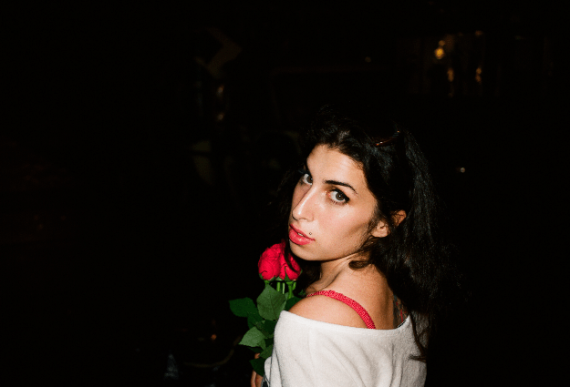

2003 - 2006

- Struggles with substance abuse
- Press scrutiny
- Tumultuous relationship with Blake Fielder-Civil

2006 — *Back to Black* Released

- Strongly influenced by heartbreak and addiction
- 1960s and soul influences
- Themes of grief and self-destruction

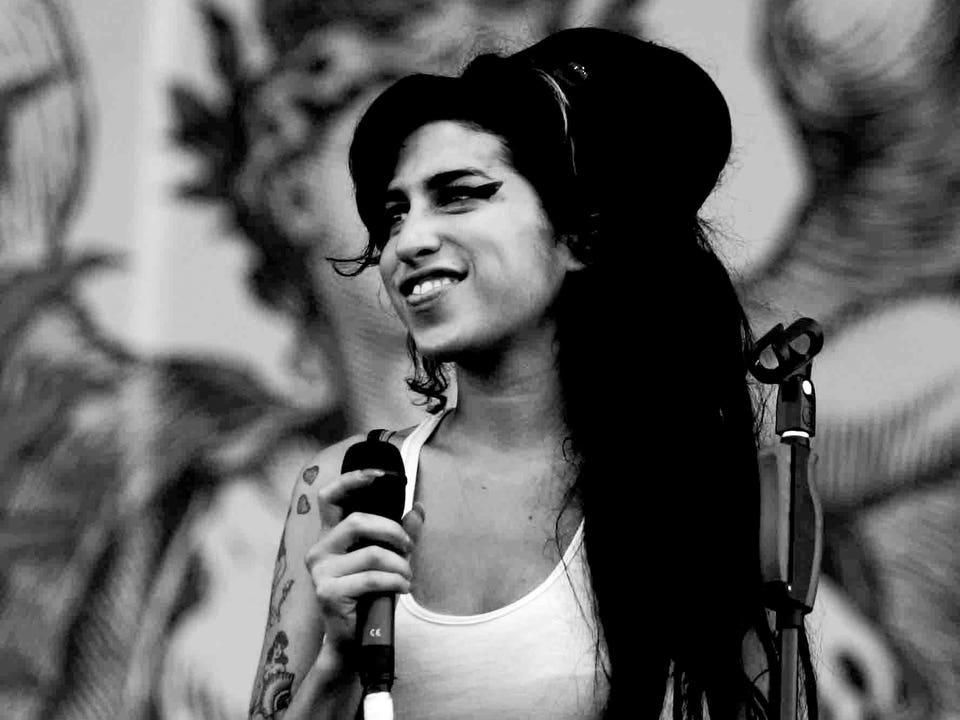

2011 — Winehouse passes away and *Lioness: Hidden Treasures* is posthumously released

- Died of alcohol poisoning in London
- *Lioness: Hidden Treasures —* Compilation of unreleased material
- Featured a mix of music spanning her early jazz and later soul-inspired work

## Valence

- *Frank* was high valence/upbeat
- *Back to Black* drops in valence, featuring sadder themes (heartbreak, substance abuse)

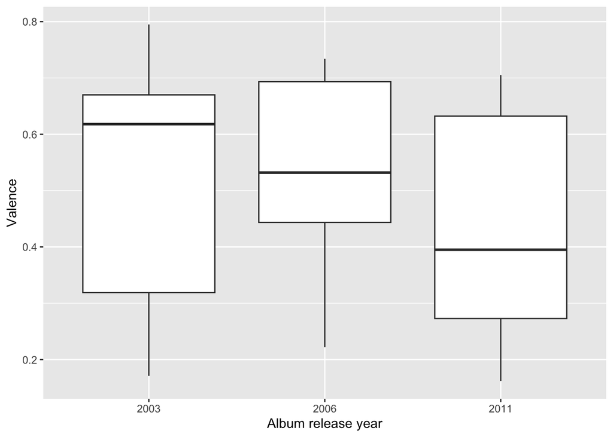

“Stronger Than Me” from *Frank* (upbeat):

[video not shown]

“Love is a Losing Game” from *Back to Black* (somber):

[video not shown]

## Energy and loudness

- *Back to Black* is louder and more energetic, suggesting more emotional intensity
- Contrasts with the smoother music from *Frank*

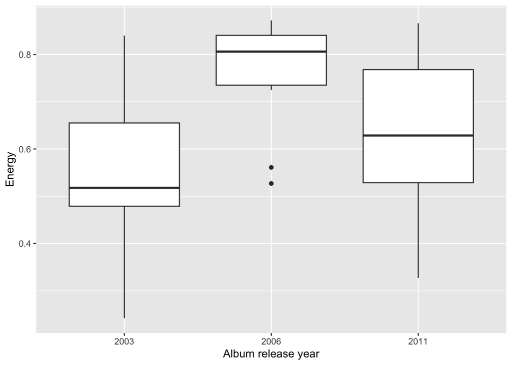

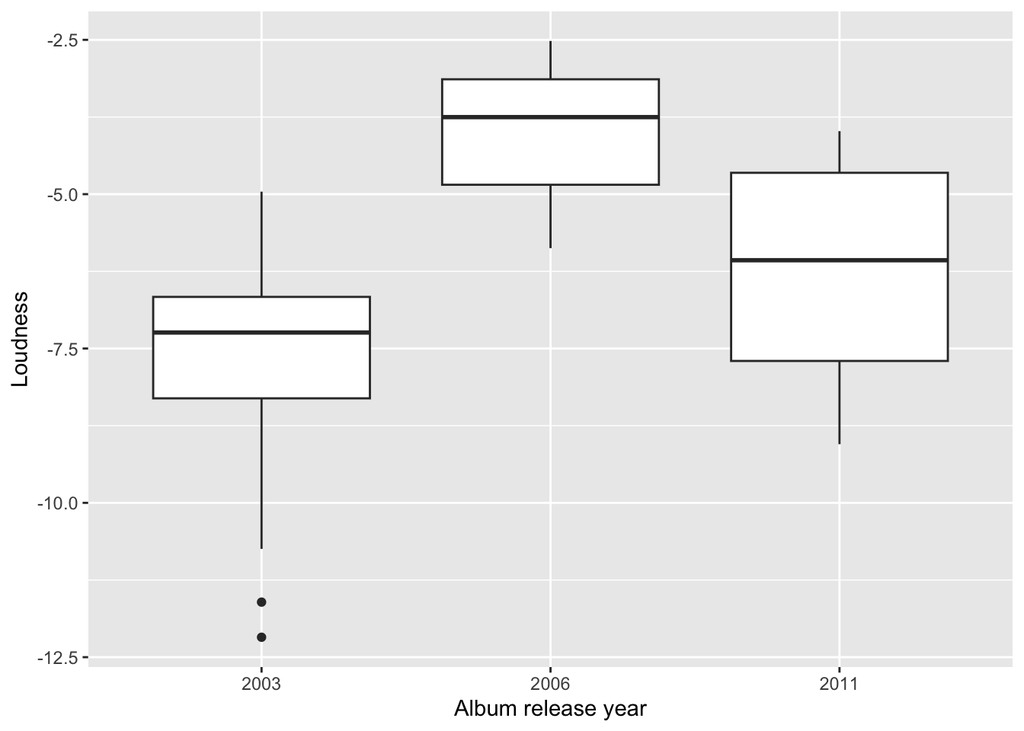

“Cherry” from *Frank* (softer vocals):

[video not shown]

“You Know I’m No Good” from *Back to Black* (high energy but melancholic):

[video not shown]

## Tempo and danceability

- *Frank* is more danceable — jazz and R&B
- *Back to Black* less so, featuring more emotional depth
- Tempo remains consistent, but beats become more dramatic

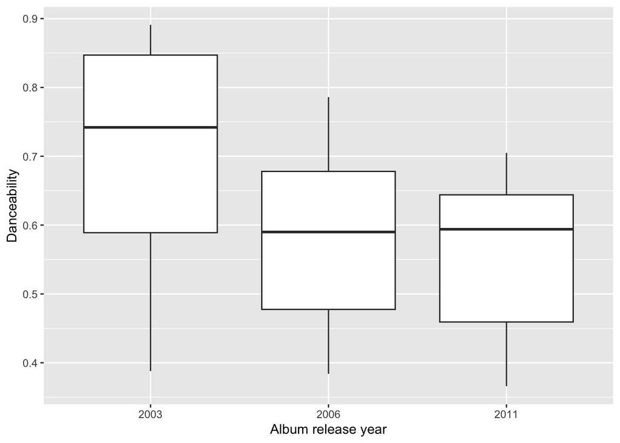

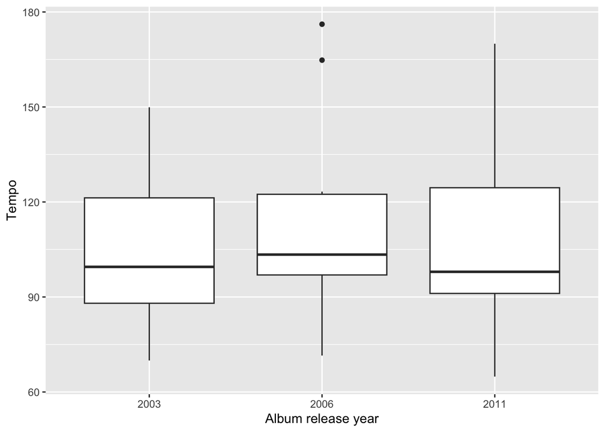

“In My Bed” from *Frank* (upbeat):

[video not shown]

“Tears Dry on Their Own” from *Back to Black* (high tempo, emotional lyrics):

[video not shown]

## Liveness

- *Frank* and *Back to Black* have studio-focused production
- *Lioness* sees higher liveness, featuring some live recordings

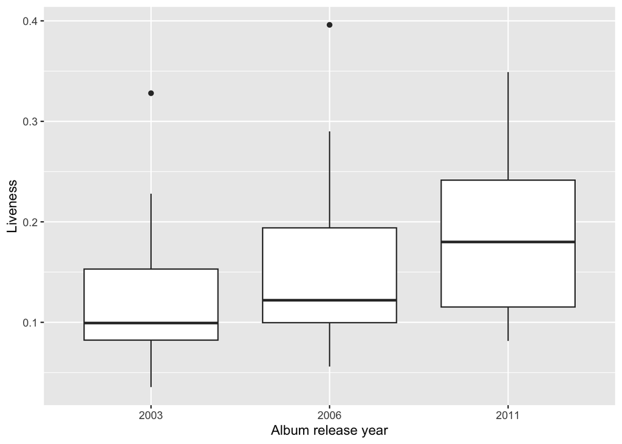

“Valerie” from *Lioness* (live):

[video not shown]